# Influence of Rating and Reasons for unpaid Loan in Prosper Lending Company

## by Abdurrahman Kareemat

## Investigation Overview

My main interest in analysing this dataset was to understand why loans could have been defaulted and charged off. I also wanted to see features that influenced a Borrower's rate and see if the prosper rating was an effective feature in determing rate, loan amount and several other features. I was also interested in the relatonship between the loan amount and rate given.

## Dataset Overview

The data analysed consists of 113,066 rows in this dataset with 17 features . Variables include loan status, prosper rating,borrower's rate, loan amount, debt to income ratio and listing category.

## Frequency of each Loan Status

There were various loan statuses ranging from completed,current, defaulted, charged off and some more. Majority of loans were completed and are current but there were still significant loans that were defaulted and charged off.

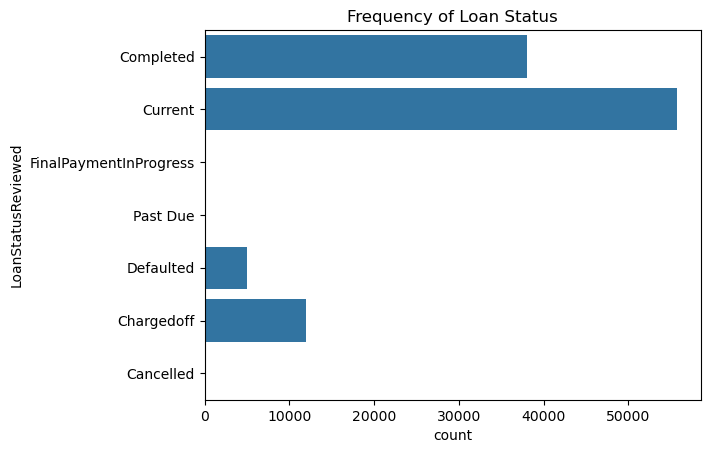

## Prosper Ratings of each Loan Status

Loans that were defaulted and charged off have a higher number of low ratings i.e. 'D','E' and 'HR' in comparison to other ratings. Although for completed loan status, the highest rating is a 'D'.

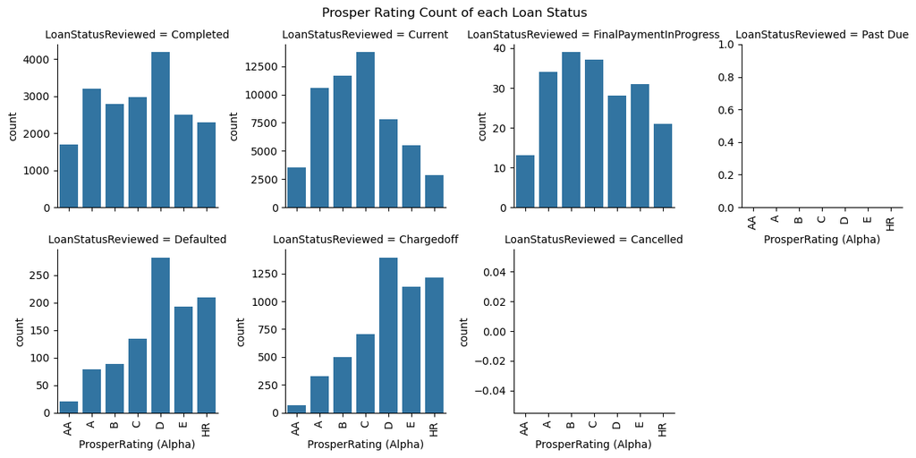

## Frequency of each Prosper Rating

Majority of Borrowers had a rating of 'C' which is an average rating. A lot of borrowers had a below average rating.

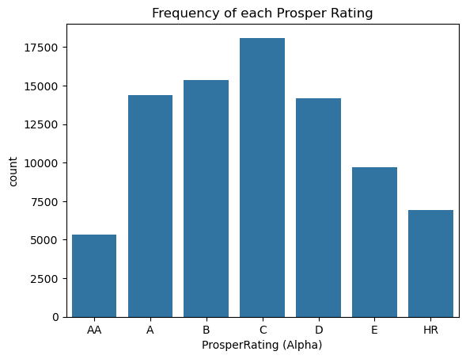

## Prosper's Rating vs Borrower's Rate

Borrower's who have high risk (low prosper rating) usually have a higher rate

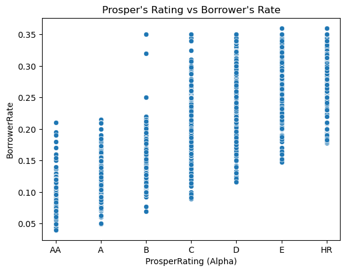

## Prosper's Rating vs Debt to Income Ratio

Borrower's who have poor prosper rating have high debt to income ratio

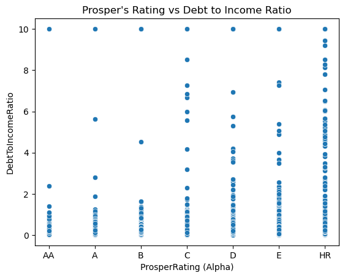

## Prosper's Rating vs Loan Amount

Lower risk (good prosper rating)could borrower higher amounts. Higher risk rating have a maximum amount of about 17,000 dollar.

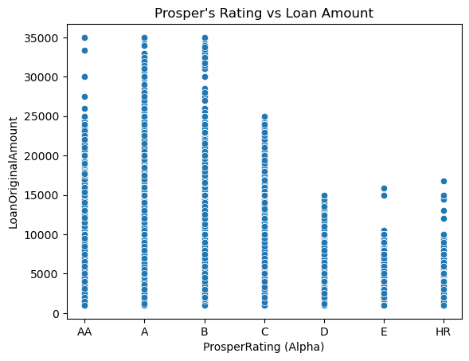

## Loan Status vs DebtToIncomeRatio for each Rating

A good number of poor ratings had high debt to income ratio and are current or have completed their loans Few numbers of high risk and high debt to income ratio had their loans charged off or defaulted People with good ratings majorly had low DTIR and majority are current on their loan or have completed it

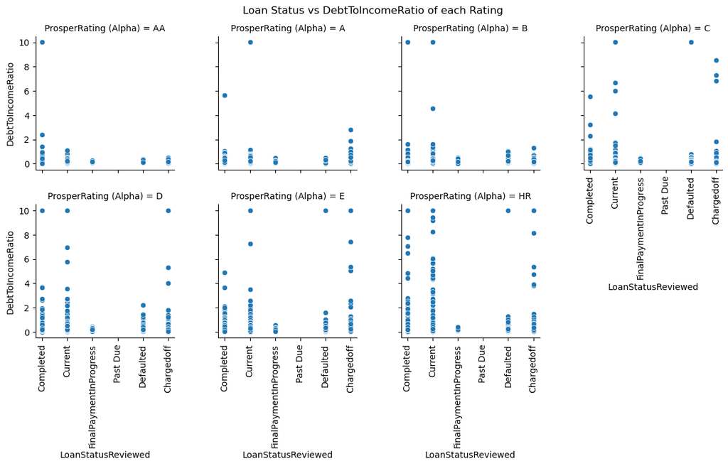

### Relationship between Income range vs Loan Amount for each Rating

Good ratings i.e AA TO C with high loan amount have a good number having high income range

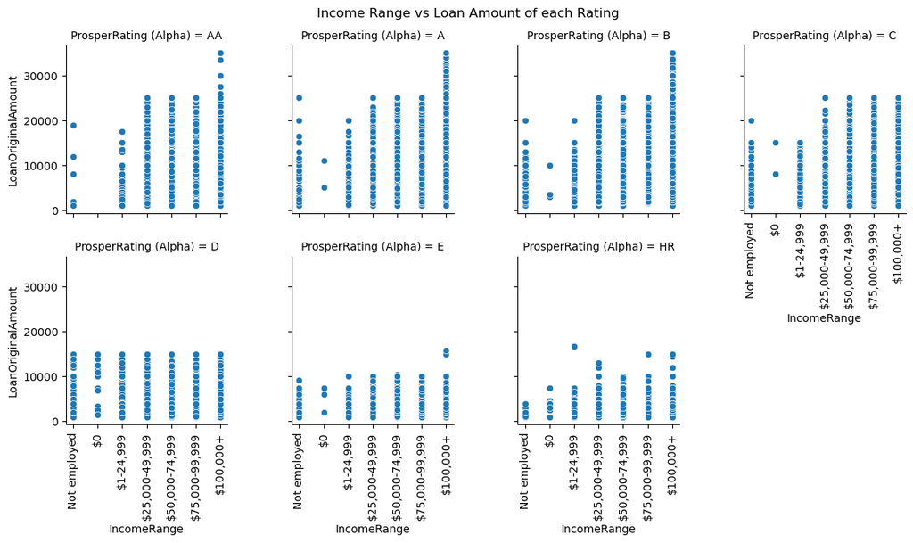

## Reasons Loans were Taken (Loan Category)

0 - Not Available, 1 - Debt Consolidation, 2 - Home Improvement, 3 - Business 7- Other

Most loans were taken out as debt consolidation followed by not available ,other, home improvement and then business

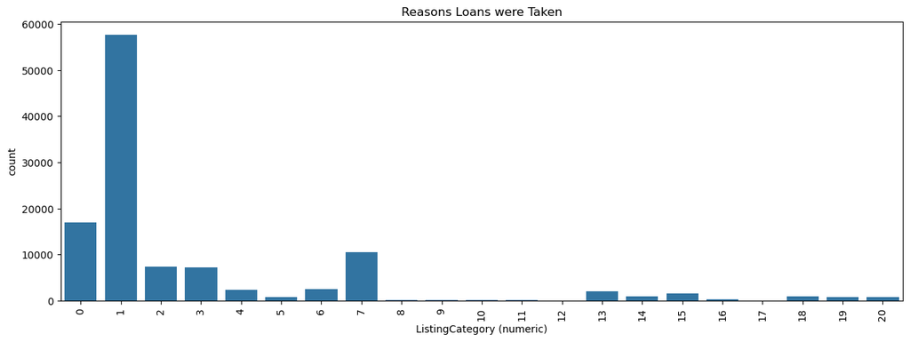

## Comparison of top Listing Category with Loan Status

More proportions of business loan were charged off and defaulted About 19.7% of people that took out loan for business were charged off and defaulted About 10.9% of people that took out loan for home improvement were charged off and defaulted About 8.00% of people that took out loan for debt consolidation were charged off and defaulted

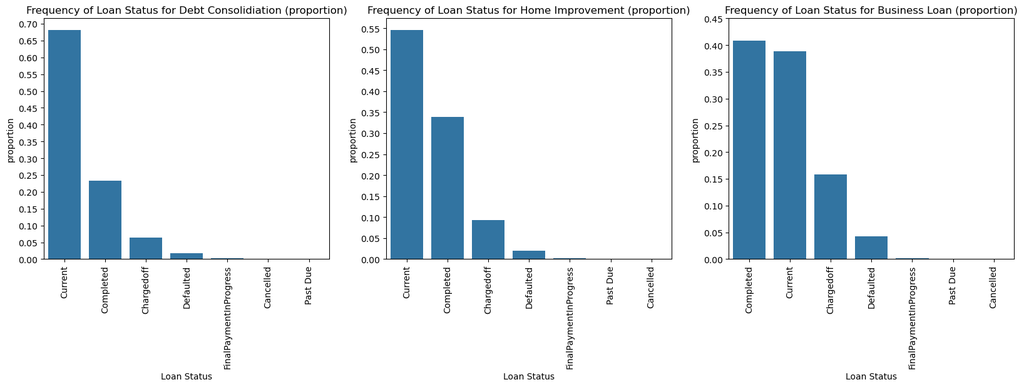

### Comparing Improvements before and after the introduction of Prosper Rating

Prosper's Rating was a feature that introduced on 2009. Seeing the impact of this feature on their transactions. For years greater than 2009, we can see a lesser proportion of charged and defaulted loan in comparison to years before 2009

## Comparing loan status before and after introduction of prosper rating

For years greater than 2009, we can see a lesser proportion of charged and defaulted loan in comparison to years before 2009

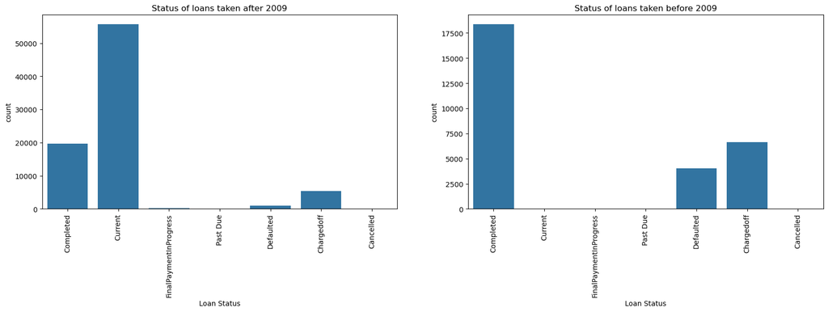

## Relationship between loan amount and rate before and after introduction of prosper rating

Good ratings like AA,A,B and C had lower rates and could loan higher amounts An increase in rate was followed by lower ratings like D,E and HR

[figure not shown]